# RNA-seq

Szymon Bzdzion

2023-05-02

# RNA-seq analysis of publicly available data from GEO.

### Title of the study: MacroH2A2 knockdown vs control RNA-seq in primary glioblastoma cells

GEO accesion number: GSE149324

**Summary**: Self-renewal is a crucial property of glioblastoma cells and is enabled by the choreographed function of chromatin regulators and transcription factors. Identifying targetable epigenetic mechanisms of self-renewal could represent an important step toward developing new and effective treatments for this universally lethal cancer. Here we uncover a targetable epigenetic axis of self-renewal mediated by the histone variant macroH2A2.

I downloaded data with using `fasterq-dump` tool

```bash
fasterq-dump SRR11607121
fasterq-dump SRR11607122
fasterq-dump SRR11607123
fasterq-dump SRR11607124
fasterq-dump SRR11607125
fasterq-dump SRR11607126
```

## Quality control and trimming

Then I performed quality control with `fastqc`

```bash
fastqc *.fastq
```

Overall quality was good

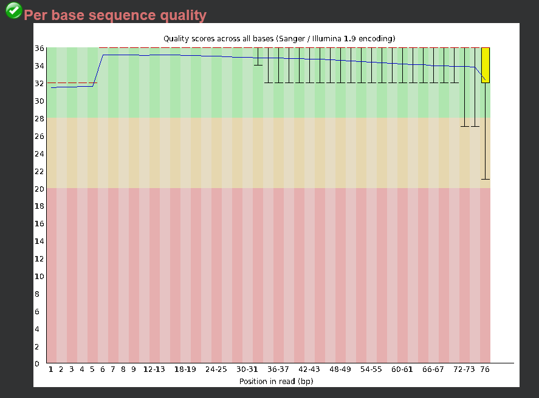

and adapter sequences were already trimmed

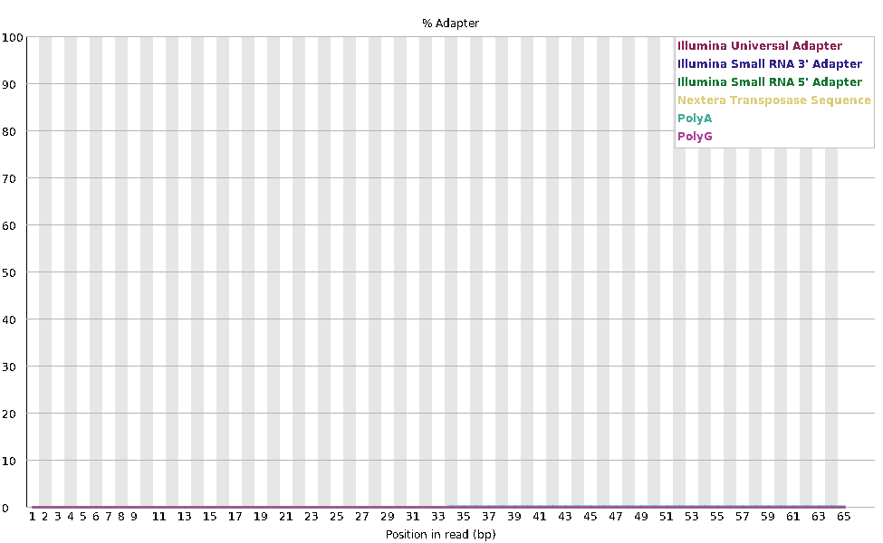

I decided to do quality trimming

```bash
trimmomatic SE SRR11607121.fastq SRR11607121_trim.fq SLIDINGWINDOW:4:30
trimmomatic SE SRR11607122.fastq SRR11607122_trim.fq SLIDINGWINDOW:4:30
trimmomatic SE SRR11607123.fastq SRR11607123_trim.fq SLIDINGWINDOW:4:30
trimmomatic SE SRR11607124.fastq SRR11607124_trim.fq SLIDINGWINDOW:4:30
trimmomatic SE SRR11607125.fastq SRR11607125_trim.fq SLIDINGWINDOW:4:30
trimmomatic SE SRR11607126.fastq SRR11607126_trim.fq SLIDINGWINDOW:4:30
```

After that i checked the quality again

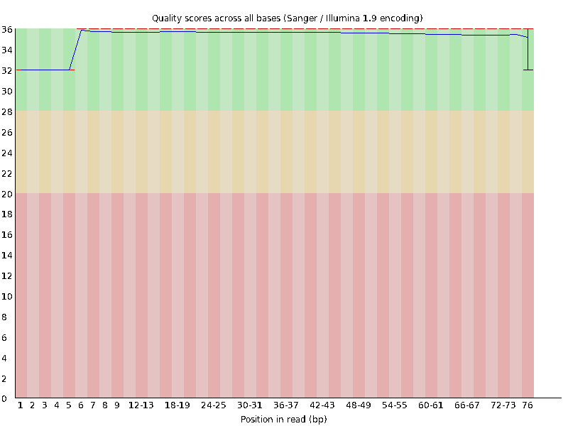

## Transcript quantification

After trimming I used `Salmon` to quantify the transcripts

While creating the index, I used `--gencode` flag to get more information from the transcript names

```bash
salmon index --gencode -t gencode.v43.transcripts.fa.gz -i HS_index
```

Then I quantified transcripts in every file

```bash
salmon quant -i HS_index -l A \
-r SRR11607121 -p 4 --validateMappings \
-o ./quants/SRR11607121

salmon quant -i HS_index -l A \
-r SRR11607122 -p 4 --validateMappings \
-o ./quants/SRR11607122

salmon quant -i HS_index -l A \
-r SRR11607123 -p 4 --validateMappings \
-o ./quants/SRR11607123

salmon quant -i HS_index -l A \
-r SRR11607124 -p 4 --validateMappings \
-o ./quants/SRR11607124

salmon quant -i HS_index -l A \
-r SRR11607125 -p 4 --validateMappings \
-o ./quants/SRR11607125

salmon quant -i HS_index -l A \
-r SRR11607126 -p 4 --validateMappings \
-o ./quants/SRR11607126
```

## Analysis in R

First, I loaded the libraries

```r
library(tidyverse)
library(DESeq2)
library(tximeta)
library(tidybulk)
library(tidySummarizedExperiment)
library(pheatmap)
library(viridis)
library(ComplexHeatmap)
library(RColorBrewer)
library(genefilter)
library(clusterProfiler)
library(enrichplot)
library(org.Hs.eg.db)
library(ggrepel)
library(ggvenn)
library(gprofiler2)
```

Then I loaded and prepared the metadata

```r
# read and manipulate the meta data
setwd("E:/Studia/Coding/Project/RNA-seq/R_project")
meta_data <- read.delim('metadata.csv', header = T, sep = ';')
meta_data
```

```
##           SRR   SampName treatment     group
## 1 SRR11607121 GSM4497750   control     shScr
## 2 SRR11607122 GSM4497751   control     shScr
## 3 SRR11607123 GSM4497752 knockdown shH2AFY2a
## 4 SRR11607124 GSM4497753 knockdown shH2AFY2a
## 5 SRR11607125 GSM4497754 knockdown shH2AFY2b
## 6 SRR11607126 GSM4497755 knockdown shH2AFY2b
```

```r
rownames(meta_data) <- meta_data$SRR
colnames(meta_data)[1] <- 'names'
meta_data
```

```
##                   names   SampName treatment     group
## SRR11607121 SRR11607121 GSM4497750   control     shScr
## SRR11607122 SRR11607122 GSM4497751   control     shScr
## SRR11607123 SRR11607123 GSM4497752 knockdown shH2AFY2a
## SRR11607124 SRR11607124 GSM4497753 knockdown shH2AFY2a
## SRR11607125 SRR11607125 GSM4497754 knockdown shH2AFY2b
## SRR11607126 SRR11607126 GSM4497755 knockdown shH2AFY2b
```

```r
# change wokring directory
setwd("E:/Studia/Coding/Project/RNA-seq")

# find the RNA-seq files
list.files(file.path(getwd(), 'Mapping/quants'))
```

```
## [1] "SRR11607121" "SRR11607122" "SRR11607123" "SRR11607124" "SRR11607125"
## [6] "SRR11607126"
```

```r
#add files path to meta data
meta_data$files <- file.path(getwd(), 'Mapping/quants', meta_data$names, 'quant.sf')
```

I used the `tximeta` package to load the transcripts data, then I mapped transcripts to genes to perform analysis on the gene level

```r
# load the RNA-seq data
se <- tximeta(meta_data)
```

```
## importing quantifications
```

```
## reading in files with read_tsv
```

```
## 1 2 3 4 5 6
## found matching transcriptome:
## [ GENCODE - Homo sapiens - release 43 ]
## loading existing TxDb created: 2023-04-19 16:55:24
## loading existing transcript ranges created: 2023-04-19 16:55:25
## fetching genome info for GENCODE
```

```r
# summarize transcripts to genes
gse <- summarizeToGene(se)
```

```
## loading existing TxDb created: 2023-04-19 16:55:24
## obtaining transcript-to-gene mapping from database
## loading existing gene ranges created: 2023-04-19 16:57:02
## summarizing abundance
## summarizing counts
## summarizing length
```

```r
gse
```

```
## # A SummarizedExperiment-tibble abstraction: 373,614 × 6
## # Features=62269 | Samples=6 | Assays=counts, abundance, length
##    .feature       .sample counts abundance length names SampName treatment group
##    <chr>          <chr>    <dbl>     <dbl>  <dbl> <chr> <chr>    <chr>     <chr>
##  1 ENSG000000000… SRR116… 1486.    7.84     2184. SRR1… GSM4497… control   shScr
##  2 ENSG000000000… SRR116…    0     0         624. SRR1… GSM4497… control   shScr
##  3 ENSG000000004… SRR116… 1322.   17.7       863. SRR1… GSM4497… control   shScr
##  4 ENSG000000004… SRR116…  344.    1.14     3491. SRR1… GSM4497… control   shScr
##  5 ENSG000000004… SRR116…  608.    3.91     1794. SRR1… GSM4497… control   shScr
##  6 ENSG000000009… SRR116…    1     0.00549  2101  SRR1… GSM4497… control   shScr
##  7 ENSG000000009… SRR116…   26.6   0.130    2358. SRR1… GSM4497… control   shScr
##  8 ENSG000000010… SRR116… 1423.   10.4      1579. SRR1… GSM4497… control   shScr
##  9 ENSG000000010… SRR116…  625.    4.95     1454. SRR1… GSM4497… control   shScr
## 10 ENSG000000011… SRR116… 2212.    7.60     3354. SRR1… GSM4497… control   shScr
## # ℹ 40 more rows
## # ℹ 7 more variables: gene_id <chr>, tx_ids <named list>, seqnames <fct>,
## #   start <int>, end <int>, width <int>, strand <fct>
```

```r
# save the SummarizedExperiment
#saveRDS(gse ,'gse.RDS')
```

The next step was exploring the data and preparing it for further analysis

```r
# explore the data
assayNames(gse)
```

```
## [1] "counts"    "abundance" "length"
```

```r
head(assay(gse))
```

```
##                    SRR11607121 SRR11607122 SRR11607123 SRR11607124 SRR11607125
## ENSG00000000003.15    1485.984    1085.259    1179.265    1176.696     946.409
## ENSG00000000005.6        0.000       0.000       0.000       0.000       0.000
## ENSG00000000419.14    1322.291    1013.413    1040.467    1263.491    1107.460
## ENSG00000000457.14     343.884     310.130     356.332     394.904     279.838
## ENSG00000000460.17     607.947     471.364     413.144     427.274     403.822
## ENSG00000000938.13       1.000       0.000       0.000       0.000       0.000
##                    SRR11607126
## ENSG00000000003.15    1024.158
## ENSG00000000005.6        0.000
## ENSG00000000419.14    1265.090
## ENSG00000000457.14     310.121
## ENSG00000000460.17     481.861
## ENSG00000000938.13       0.000
```

```r
colSums(assay(gse))
```

```
## SRR11607121 SRR11607122 SRR11607123 SRR11607124 SRR11607125 SRR11607126
##    31857445    24370511    29988500    31351011    27998952    32721521
```

```r
rowRanges(gse)
```

```
## GRanges object with 62269 ranges and 2 metadata columns:
##                      seqnames              ranges strand |            gene_id
##                         <Rle>           <IRanges>  <Rle> |        <character>
##   ENSG00000000003.15     chrX 100627108-100639991      - | ENSG00000000003.15
##    ENSG00000000005.6     chrX 100584936-100599885      + |  ENSG00000000005.6
##   ENSG00000000419.14    chr20   50934867-50959140      - | ENSG00000000419.14
##   ENSG00000000457.14     chr1 169849631-169894267      - | ENSG00000000457.14
##   ENSG00000000460.17     chr1 169662007-169854080      + | ENSG00000000460.17
##                  ...      ...                 ...    ... .                ...
##    ENSG00000291313.1    chr14 103334237-103335932      + |  ENSG00000291313.1
##    ENSG00000291314.1     chrX   10566888-10576955      - |  ENSG00000291314.1
##    ENSG00000291315.1     chr3   40312086-40312214      + |  ENSG00000291315.1
##    ENSG00000291316.1     chr8 144449582-144465430      - |  ENSG00000291316.1
##    ENSG00000291317.1     chr8 144463817-144465667      - |  ENSG00000291317.1
##                                                                          tx_ids
##                                                                 <CharacterList>
##   ENSG00000000003.15  ENST00000373020.9,ENST00000612152.4,ENST00000614008.4,...
##    ENSG00000000005.6                        ENST00000373031.5,ENST00000485971.1
##   ENSG00000000419.14 ENST00000466152.5,ENST00000371582.8,ENST00000371588.10,...
##   ENSG00000000457.14 ENST00000367771.11,ENST00000367770.5,ENST00000367772.8,...
##   ENSG00000000460.17  ENST00000498289.5,ENST00000472795.5,ENST00000359326.9,...
##                  ...                                                        ...
##    ENSG00000291313.1                                          ENST00000706947.1
##    ENSG00000291314.1                                          ENST00000706950.1
##    ENSG00000291315.1                                          ENST00000706951.1
##    ENSG00000291316.1                        ENST00000438911.6,ENST00000526887.5
##    ENSG00000291317.1 ENST00000403000.6,ENST00000424149.6,ENST00000306145.10,...
##   -------
##   seqinfo: 25 sequences (1 circular) from hg38 genome
```

```r
seqinfo(rowRanges(gse))
```

```
## Seqinfo object with 25 sequences (1 circular) from hg38 genome:
##   seqnames seqlengths isCircular genome
##   chr1      248956422      FALSE   hg38
##   chr2      242193529      FALSE   hg38
##   chr3      198295559      FALSE   hg38
##   chr4      190214555      FALSE   hg38
##   chr5      181538259      FALSE   hg38
##   ...             ...        ...    ...
##   chr21      46709983      FALSE   hg38
##   chr22      50818468      FALSE   hg38
##   chrX      156040895      FALSE   hg38
##   chrY       57227415      FALSE   hg38
##   chrM          16569       TRUE   hg38
```

```r
colData(gse)
```

```
## DataFrame with 6 rows and 4 columns
##                   names    SampName   treatment       group
##             <character> <character> <character> <character>
## SRR11607121 SRR11607121  GSM4497750     control       shScr
## SRR11607122 SRR11607122  GSM4497751     control       shScr
## SRR11607123 SRR11607123  GSM4497752   knockdown   shH2AFY2a
## SRR11607124 SRR11607124  GSM4497753   knockdown   shH2AFY2a
## SRR11607125 SRR11607125  GSM4497754   knockdown   shH2AFY2b
## SRR11607126 SRR11607126  GSM4497755   knockdown   shH2AFY2b
```

```r
# change columns to factors
gse$group <- factor(gse$group)
gse$treatment <- factor(gse$treatment)

#relevel group column - set the reference level
levels(gse$group)
```

```
## [1] "shH2AFY2a" "shH2AFY2b" "shScr"
```

```r
gse$group <- relevel(gse$group, ref = 'shScr')


# check reads in milions
round( colSums(assay(gse)) / 1e6, 1)
```

```
## SRR11607121 SRR11607122 SRR11607123 SRR11607124 SRR11607125 SRR11607126
##        31.9        24.4        30.0        31.4        28.0        32.7
```

I created the `DESeqDataSet` filtered the data and performed variance stabilization with two methods `vst` and `rlog` - to prepare the data for EDA

```r
# create DESeqDataSet
dds <- DESeqDataSet(gse, design = ~ group)
```

```
## using counts and average transcript lengths from tximeta
```

```r
dds
```

```
## # A SummarizedExperiment-tibble abstraction: 373,614 × 6
## # Features=62269 | Samples=6 | Assays=counts, abundance, avgTxLength
##    .feature  .sample counts abundance avgTxLength names SampName treatment group
##    <chr>     <chr>    <int>     <dbl>       <dbl> <chr> <chr>    <fct>     <fct>
##  1 ENSG0000… SRR116…   1486   7.84          2184. SRR1… GSM4497… control   shScr
##  2 ENSG0000… SRR116…      0   0              624. SRR1… GSM4497… control   shScr
##  3 ENSG0000… SRR116…   1322  17.7            863. SRR1… GSM4497… control   shScr
##  4 ENSG0000… SRR116…    344   1.14          3491. SRR1… GSM4497… control   shScr
##  5 ENSG0000… SRR116…    608   3.91          1794. SRR1… GSM4497… control   shScr
##  6 ENSG0000… SRR116…      1   0.00549       2101  SRR1… GSM4497… control   shScr
##  7 ENSG0000… SRR116…     27   0.130         2358. SRR1… GSM4497… control   shScr
##  8 ENSG0000… SRR116…   1423  10.4           1579. SRR1… GSM4497… control   shScr
##  9 ENSG0000… SRR116…    625   4.95          1454. SRR1… GSM4497… control   shScr
## 10 ENSG0000… SRR116…   2212   7.60          3354. SRR1… GSM4497… control   shScr
## # ℹ 40 more rows
## # ℹ 7 more variables: gene_id <chr>, tx_ids <named list>, seqnames <fct>,
## #   start <int>, end <int>, width <int>, strand <fct>
```

```r
# filter the data - keep only genes with enough reads
keep <- rowSums(counts(dds) >= 10) >= 2
dds <- dds[keep, ]
dds
```

```
## # A SummarizedExperiment-tibble abstraction: 134,058 × 6
## # Features=22343 | Samples=6 | Assays=counts, abundance, avgTxLength
##    .feature  .sample counts abundance avgTxLength names SampName treatment group
##    <chr>     <chr>    <int>     <dbl>       <dbl> <chr> <chr>    <fct>     <fct>
##  1 ENSG0000… SRR116…   1486     7.84        2184. SRR1… GSM4497… control   shScr
##  2 ENSG0000… SRR116…   1322    17.7          863. SRR1… GSM4497… control   shScr
##  3 ENSG0000… SRR116…    344     1.14        3491. SRR1… GSM4497… control   shScr
##  4 ENSG0000… SRR116…    608     3.91        1794. SRR1… GSM4497… control   shScr
##  5 ENSG0000… SRR116…     27     0.130       2358. SRR1… GSM4497… control   shScr
##  6 ENSG0000… SRR116…   1423    10.4         1579. SRR1… GSM4497… control   shScr
##  7 ENSG0000… SRR116…    625     4.95        1454. SRR1… GSM4497… control   shScr
##  8 ENSG0000… SRR116…   2212     7.60        3354. SRR1… GSM4497… control   shScr
##  9 ENSG0000… SRR116…    117     0.641       2102. SRR1… GSM4497… control   shScr
## 10 ENSG0000… SRR116…    317     1.00        3656. SRR1… GSM4497… control   shScr
## # ℹ 40 more rows
## # ℹ 7 more variables: gene_id <chr>, tx_ids <named list>, seqnames <fct>,
## #   start <int>, end <int>, width <int>, strand <fct>
```

```r
# variance stabilization - transformation for EDA
vsd <- vst(dds, blind = F)
```

```
## using 'avgTxLength' from assays(dds), correcting for library size
```

```r
rld <- rlog(dds, blind = F)
```

```
## using 'avgTxLength' from assays(dds), correcting for library size
```

I examined the variance to pick a better method for further visualization

```r
# visualize variance
dds <- estimateSizeFactors(dds)
```

```
## using 'avgTxLength' from assays(dds), correcting for library size
```

```r
df <- bind_rows(
  as_data_frame(log2(counts(dds, normalized=TRUE)[,1:2] + 1)) %>% mutate(transformation = 'log2(x+1)'),
  as_data_frame(assay(vsd)[,1:2]) %>% mutate(transformation = 'vst'),
  as_data_frame(assay(rld)[,1:2]) %>% mutate(transformation = 'rlog')
)
```

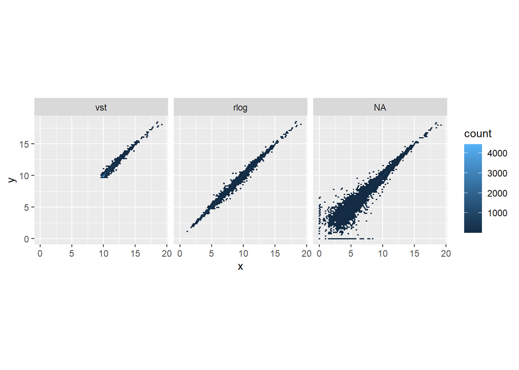

```r
colnames(df)[1:2] <- c("x", 'y')

lvls <- c("log2(x + 1)", "vst", "rlog")
df$transformation <- factor(df$transformation, levels=lvls)

ggplot(df, aes(x = x, y = y)) + geom_hex(bins = 80) +
  coord_fixed() + facet_grid( . ~ transformation)
```

Data after `rlog` transformation looked better so I decided to use this data for further exploration

I checked the distance between samples using `dist` and `pheatmap`

```r
#check distance between samples
sample_dists <- dist(t(assay(rld)))
sample_dists
```

```
##             SRR11607121 SRR11607122 SRR11607123 SRR11607124 SRR11607125
## SRR11607122    21.75991
## SRR11607123    45.13970    46.87113
## SRR11607124    44.36321    45.56971    19.71347
## SRR11607125    42.50478    44.16320    34.30536    33.73970
## SRR11607126    42.56840    44.20068    34.36736    34.03874    19.62141
```

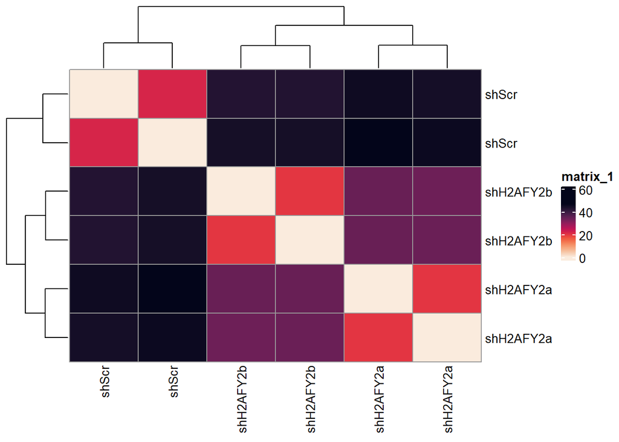

```r
sample_dists <- as.matrix(sample_dists)
colnames(sample_dists) <- dds$group
rownames(sample_dists) <- dds$group

pheatmap(sample_dists, color = rev(viridis::rocket(100)))
```

As expected control samples (shScr) were closer to each other than to test samples. Similarly, test samples of the same type had a lower distance to each other than test samples of different type.

### PCA analysis

I made PCA plot to examine the differences between samples

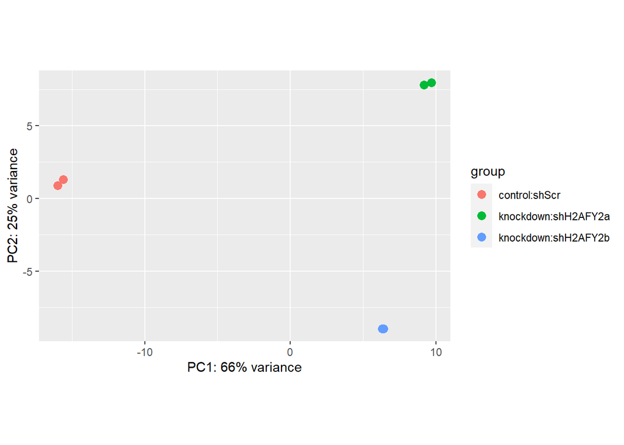

```r
plotPCA(rld, intgroup = c('treatment', 'group'))
```

```r
rm(se, meta_data)
```

The results were similar to the distance heatmap. The biggest difference was between control and test samples (PC1), but there was also some difference between types of knockout (PC2)

## Results

### control vs shB

```r
# differential expression analysis
dds <- DESeq(dds)
#get the results
res_ctrl_B <- results(dds)

#shrinking log fold changes for visualization and functional enrichment
res_ctrl_B_df <- lfcShrink(dds, coef = 'group_shH2AFY2b_vs_shScr', type = 'apeglm')
```

```
## using 'apeglm' for LFC shrinkage. If used in published research, please cite:
##     Zhu, A., Ibrahim, J.G., Love, M.I. (2018) Heavy-tailed prior distributions for
##     sequence count data: removing the noise and preserving large differences.
##     Bioinformatics. https://doi.org/10.1093/bioinformatics/bty895
```

```r
res_ctrl_B_df <- as_tibble(res_ctrl_B, rownames = 'ENSEMBL')
res_ctrl_B_df %>%
  arrange(padj)
```

```
## # A tibble: 22,343 × 7
##    ENSEMBL            baseMean log2FoldChange  lfcSE  stat    pvalue      padj
##    <chr>                 <dbl>          <dbl>  <dbl> <dbl>     <dbl>     <dbl>
##  1 ENSG00000101203.17    9433.           4.88 0.110   44.5 0         0
##  2 ENSG00000130600.21   14133.           2.92 0.0715  40.9 0         0
##  3 ENSG00000139219.19    1722.           4.13 0.137   30.1 1.40e-198 9.03e-195
##  4 ENSG00000164687.11    3170.           2.99 0.110   27.3 7.49e-164 3.62e-160
##  5 ENSG00000128564.8    39892.           2.36 0.0937  25.2 1.87e-140 7.23e-137
##  6 ENSG00000138759.20     951.           4.63 0.190   24.4 8.45e-132 2.72e-128
##  7 ENSG00000143127.13    1509.           3.22 0.136   23.7 3.37e-124 9.30e-121
##  8 ENSG00000145681.11    1232.           4.02 0.176   22.8 3.06e-115 7.39e-112
##  9 ENSG00000095015.6    10266.           1.65 0.0745  22.2 2.14e-109 4.59e-106
## 10 ENSG00000130477.16    1579.          -2.54 0.115  -22.2 3.64e-109 7.03e-106
## # ℹ 22,333 more rows
```

I added the column with symbols mapping ENSEMBL IDs to gene symbols  
I also added a threshold column for the volcano plot and sorted the data frame

```r
# check database
org.Hs.eg.db
```

```
## OrgDb object:
## | DBSCHEMAVERSION: 2.1
## | Db type: OrgDb
## | Supporting package: AnnotationDbi
## | DBSCHEMA: HUMAN_DB
## | ORGANISM: Homo sapiens
## | SPECIES: Human
## | EGSOURCEDATE: 2022-Sep12
## | EGSOURCENAME: Entrez Gene
## | EGSOURCEURL: ftp://ftp.ncbi.nlm.nih.gov/gene/DATA
## | CENTRALID: EG
## | TAXID: 9606
## | GOSOURCENAME: Gene Ontology
## | GOSOURCEURL: http://current.geneontology.org/ontology/go-basic.obo
## | GOSOURCEDATE: 2022-07-01
## | GOEGSOURCEDATE: 2022-Sep12
## | GOEGSOURCENAME: Entrez Gene
## | GOEGSOURCEURL: ftp://ftp.ncbi.nlm.nih.gov/gene/DATA
## | KEGGSOURCENAME: KEGG GENOME
## | KEGGSOURCEURL: ftp://ftp.genome.jp/pub/kegg/genomes
## | KEGGSOURCEDATE: 2011-Mar15
## | GPSOURCENAME: UCSC Genome Bioinformatics (Homo sapiens)
## | GPSOURCEURL:
## | GPSOURCEDATE: 2022-Aug31
## | ENSOURCEDATE: 2022-Jun28
## | ENSOURCENAME: Ensembl
## | ENSOURCEURL: ftp://ftp.ensembl.org/pub/current_fasta
## | UPSOURCENAME: Uniprot
## | UPSOURCEURL: http://www.UniProt.org/
## | UPSOURCEDATE: Fri Sep 23 16:26:35 2022
```

```
##
## Please see: help('select') for usage information
```

```r
keytypes(org.Hs.eg.db)
```

```
##  [1] "ACCNUM"       "ALIAS"        "ENSEMBL"      "ENSEMBLPROT"  "ENSEMBLTRANS"
##  [6] "ENTREZID"     "ENZYME"       "EVIDENCE"     "EVIDENCEALL"  "GENENAME"
## [11] "GENETYPE"     "GO"           "GOALL"        "IPI"          "MAP"
## [16] "OMIM"         "ONTOLOGY"     "ONTOLOGYALL"  "PATH"         "PFAM"
## [21] "PMID"         "PROSITE"      "REFSEQ"       "SYMBOL"       "UCSCKG"
## [26] "UNIPROT"
```

```r
# remove version digits from ENSEMBL name
res_ctrl_B_df$ENSEMBL <- gsub('\\.\\d+', "", res_ctrl_B_df$ENSEMBL)

# map ENSEMBL IDs to gene symbols
res_ctrl_B_df$symbol <- mapIds(org.Hs.eg.db, keys = res_ctrl_B_df$ENSEMBL, keytype = 'ENSEMBL', column = 'SYMBOL')
# check top significant genes
res_ctrl_B_df %>%
  arrange(padj)
```

```
## # A tibble: 22,343 × 8
##    ENSEMBL       baseMean log2FoldChange  lfcSE  stat    pvalue      padj symbol
##    <chr>            <dbl>          <dbl>  <dbl> <dbl>     <dbl>     <dbl> <chr>
##  1 ENSG00000101…    9433.           4.88 0.110   44.5 0         0         COL20…
##  2 ENSG00000130…   14133.           2.92 0.0715  40.9 0         0         H19
##  3 ENSG00000139…    1722.           4.13 0.137   30.1 1.40e-198 9.03e-195 COL2A1
##  4 ENSG00000164…    3170.           2.99 0.110   27.3 7.49e-164 3.62e-160 FABP5
##  5 ENSG00000128…   39892.           2.36 0.0937  25.2 1.87e-140 7.23e-137 VGF
##  6 ENSG00000138…     951.           4.63 0.190   24.4 8.45e-132 2.72e-128 FRAS1
##  7 ENSG00000143…    1509.           3.22 0.136   23.7 3.37e-124 9.30e-121 ITGA10
##  8 ENSG00000145…    1232.           4.02 0.176   22.8 3.06e-115 7.39e-112 HAPLN1
##  9 ENSG00000095…   10266.           1.65 0.0745  22.2 2.14e-109 4.59e-106 MAP3K1
## 10 ENSG00000130…    1579.          -2.54 0.115  -22.2 3.64e-109 7.03e-106 UNC13A
## # ℹ 22,333 more rows
```

```r
# add threshold column
res_ctrl_B_df <- res_ctrl_B_df %>%
  mutate(threshold = (log2FoldChange > 2 & padj < 0.05) | (log2FoldChange < -2 & padj < 0.05))
# order the data frame
res_ctrl_B_df <- res_ctrl_B_df %>%
  arrange(padj)

res_ctrl_B_df
```

```
## # A tibble: 22,343 × 9
##    ENSEMBL       baseMean log2FoldChange  lfcSE  stat    pvalue      padj symbol
##    <chr>            <dbl>          <dbl>  <dbl> <dbl>     <dbl>     <dbl> <chr>
##  1 ENSG00000101…    9433.           4.88 0.110   44.5 0         0         COL20…
##  2 ENSG00000130…   14133.           2.92 0.0715  40.9 0         0         H19
##  3 ENSG00000139…    1722.           4.13 0.137   30.1 1.40e-198 9.03e-195 COL2A1
##  4 ENSG00000164…    3170.           2.99 0.110   27.3 7.49e-164 3.62e-160 FABP5
##  5 ENSG00000128…   39892.           2.36 0.0937  25.2 1.87e-140 7.23e-137 VGF
##  6 ENSG00000138…     951.           4.63 0.190   24.4 8.45e-132 2.72e-128 FRAS1
##  7 ENSG00000143…    1509.           3.22 0.136   23.7 3.37e-124 9.30e-121 ITGA10
##  8 ENSG00000145…    1232.           4.02 0.176   22.8 3.06e-115 7.39e-112 HAPLN1
##  9 ENSG00000095…   10266.           1.65 0.0745  22.2 2.14e-109 4.59e-106 MAP3K1
## 10 ENSG00000130…    1579.          -2.54 0.115  -22.2 3.64e-109 7.03e-106 UNC13A
## # ℹ 22,333 more rows
## # ℹ 1 more variable: threshold <lgl>
```

Volcano plot

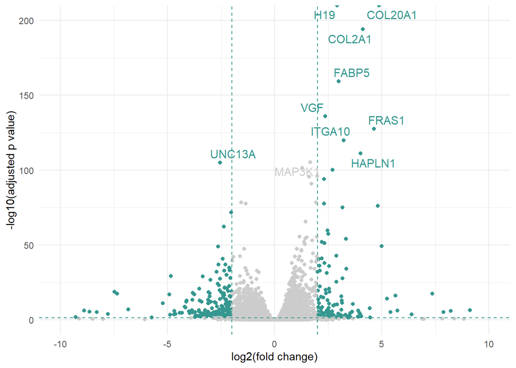

```r
# volcano plot - control vs shB
ggplot(res_ctrl_B_df, aes(log2FoldChange, -log10(padj), color = threshold)) +
  geom_point() +
  geom_vline(xintercept = 2, linetype = 2, color = '#35978F')+
  geom_vline(xintercept = -2, linetype = 2, color = '#35978F') +
  geom_hline(yintercept = -log10(0.05), linetype = 2, color = "#35978F")+
  geom_text_repel(data = res_ctrl_B_df[1:10,],aes(log2FoldChange, -log10(padj), label = symbol), size = 4) +
  scale_color_manual(values = c('gray80', "#35978F"), guide="none") +
  xlim(-10, 10) +
  ylim(0, 200) +
  labs(x='log2(fold change)', y='-log10(adjusted p value)') +
  theme_minimal()
```

The results table and volcano plot showed that among other genes: COL20A1, H19, and COL2A1 were upregulated and UNC13A was downregulated in shH2AFY2b compared to control samples

## I did the same analysis for different comparisons - here are the results

### control vs shA

```r
# get the results
res_ctrl_A <- results(dds, contrast = c("group", "shScr", "shH2AFY2a"))
res_ctrl_A
```

```
## log2 fold change (MLE): group shScr vs shH2AFY2a
## Wald test p-value: group shScr vs shH2AFY2a
## DataFrame with 22343 rows and 6 columns
##                     baseMean log2FoldChange     lfcSE      stat    pvalue
##                    <numeric>      <numeric> <numeric> <numeric> <numeric>
## ENSG00000000003.15 1148.0299       0.249847  0.120300  2.076872 0.0378134
## ENSG00000000419.14 1164.6156       0.096740  0.131657  0.734788 0.4624688
## ENSG00000000457.14  332.2988      -0.191967  0.200728 -0.956353 0.3388940
## ENSG00000000460.17  467.8580       0.456315  0.184279  2.476211 0.0132785
## ENSG00000000971.17   31.1518       0.449742  0.625586  0.718914 0.4721940
## ...                      ...            ...       ...       ...       ...
## ENSG00000291312.1    86.3567      -0.317087  0.372516 -0.851204  0.394656
## ENSG00000291313.1    60.1491       0.251805  0.516390  0.487626  0.625815
## ENSG00000291315.1   112.7547      -0.363760  0.317178 -1.146862  0.251439
## ENSG00000291316.1   328.7764       0.347413  0.250857  1.384906  0.166081
## ENSG00000291317.1   249.5546      -0.250383  0.224269 -1.116441  0.264234
##                         padj
##                    <numeric>
## ENSG00000000003.15 0.1079599
## ENSG00000000419.14 0.6689111
## ENSG00000000457.14 0.5499011
## ENSG00000000460.17 0.0462105
## ENSG00000000971.17 0.6774036
## ...                      ...
## ENSG00000291312.1   0.604987
## ENSG00000291313.1   0.793463
## ENSG00000291315.1   0.450263
## ENSG00000291316.1   0.337578
## ENSG00000291317.1   0.465081
```

```r
# change to data frame
res_ctrl_A_df <- lfcShrink(dds, coef = 'group_shH2AFY2a_vs_shScr', type = 'apeglm')
```

```
## using 'apeglm' for LFC shrinkage. If used in published research, please cite:
##     Zhu, A., Ibrahim, J.G., Love, M.I. (2018) Heavy-tailed prior distributions for
##     sequence count data: removing the noise and preserving large differences.
##     Bioinformatics. https://doi.org/10.1093/bioinformatics/bty895
```

```r
res_ctrl_A_df <- as_tibble(res_ctrl_A, rownames = 'ENSEMBL')
res_ctrl_A_df %>%
  arrange(padj)
```

```
## # A tibble: 22,343 × 7
##    ENSEMBL            baseMean log2FoldChange  lfcSE  stat    pvalue      padj
##    <chr>                 <dbl>          <dbl>  <dbl> <dbl>     <dbl>     <dbl>
##  1 ENSG00000101203.17    9433.          -4.69 0.110  -42.8 0         0
##  2 ENSG00000145681.11    1232.          -5.07 0.174  -29.0 1.63e-185 1.43e-181
##  3 ENSG00000143127.13    1509.          -3.71 0.135  -27.5 5.31e-166 3.11e-162
##  4 ENSG00000129824.16     904.           4.85 0.188   25.7 4.23e-146 1.86e-142
##  5 ENSG00000134853.12   31778.          -1.51 0.0591 -25.6 2.51e-144 8.82e-141
##  6 ENSG00000130600.21   14133.          -1.80 0.0718 -25.1 3.78e-139 1.11e-135
##  7 ENSG00000139219.19    1722.          -3.43 0.138  -24.8 3.78e-136 9.49e-133
##  8 ENSG00000183117.20     511.           7.64 0.310   24.6 1.49e-133 3.27e-130
##  9 ENSG00000165246.15     830.           5.39 0.232   23.3 1.20e-119 2.34e-116
## 10 ENSG00000173546.7    13989.          -1.90 0.0821 -23.1 2.27e-118 3.99e-115
## # ℹ 22,333 more rows
```

```r
# remove gene version digits from ENSEMBLE IDs
res_ctrl_A_df$ENSEMBL <- gsub('\\.\\d+', "", res_ctrl_A_df$ENSEMBL)

# map ENSEMBLE IDs to gene symbols
res_ctrl_A_df$symbol <- mapIds(org.Hs.eg.db, keys = res_ctrl_A_df$ENSEMBL, keytype = 'ENSEMBL', column = 'SYMBOL')
res_ctrl_A_df %>%
  arrange(padj)
```

```
## # A tibble: 22,343 × 8
##    ENSEMBL       baseMean log2FoldChange  lfcSE  stat    pvalue      padj symbol
##    <chr>            <dbl>          <dbl>  <dbl> <dbl>     <dbl>     <dbl> <chr>
##  1 ENSG00000101…    9433.          -4.69 0.110  -42.8 0         0         COL20…
##  2 ENSG00000145…    1232.          -5.07 0.174  -29.0 1.63e-185 1.43e-181 HAPLN1
##  3 ENSG00000143…    1509.          -3.71 0.135  -27.5 5.31e-166 3.11e-162 ITGA10
##  4 ENSG00000129…     904.           4.85 0.188   25.7 4.23e-146 1.86e-142 RPS4Y1
##  5 ENSG00000134…   31778.          -1.51 0.0591 -25.6 2.51e-144 8.82e-141 PDGFRA
##  6 ENSG00000130…   14133.          -1.80 0.0718 -25.1 3.78e-139 1.11e-135 H19
##  7 ENSG00000139…    1722.          -3.43 0.138  -24.8 3.78e-136 9.49e-133 COL2A1
##  8 ENSG00000183…     511.           7.64 0.310   24.6 1.49e-133 3.27e-130 CSMD1
##  9 ENSG00000165…     830.           5.39 0.232   23.3 1.20e-119 2.34e-116 NLGN4Y
## 10 ENSG00000173…   13989.          -1.90 0.0821 -23.1 2.27e-118 3.99e-115 CSPG4
## # ℹ 22,333 more rows
```

```r
# add threshold data
res_ctrl_A_df <- res_ctrl_A_df %>%
  mutate(threshold = (log2FoldChange > 2 & padj < 0.05) | (log2FoldChange < -2 & padj < 0.05))
# order the data frame
res_ctrl_A_df <- res_ctrl_A_df %>%
  arrange(padj)
res_ctrl_A_df
```

```
## # A tibble: 22,343 × 9
##    ENSEMBL       baseMean log2FoldChange  lfcSE  stat    pvalue      padj symbol
##    <chr>            <dbl>          <dbl>  <dbl> <dbl>     <dbl>     <dbl> <chr>
##  1 ENSG00000101…    9433.          -4.69 0.110  -42.8 0         0         COL20…
##  2 ENSG00000145…    1232.          -5.07 0.174  -29.0 1.63e-185 1.43e-181 HAPLN1
##  3 ENSG00000143…    1509.          -3.71 0.135  -27.5 5.31e-166 3.11e-162 ITGA10
##  4 ENSG00000129…     904.           4.85 0.188   25.7 4.23e-146 1.86e-142 RPS4Y1
##  5 ENSG00000134…   31778.          -1.51 0.0591 -25.6 2.51e-144 8.82e-141 PDGFRA
##  6 ENSG00000130…   14133.          -1.80 0.0718 -25.1 3.78e-139 1.11e-135 H19
##  7 ENSG00000139…    1722.          -3.43 0.138  -24.8 3.78e-136 9.49e-133 COL2A1
##  8 ENSG00000183…     511.           7.64 0.310   24.6 1.49e-133 3.27e-130 CSMD1
##  9 ENSG00000165…     830.           5.39 0.232   23.3 1.20e-119 2.34e-116 NLGN4Y
## 10 ENSG00000173…   13989.          -1.90 0.0821 -23.1 2.27e-118 3.99e-115 CSPG4
## # ℹ 22,333 more rows
## # ℹ 1 more variable: threshold <lgl>
```

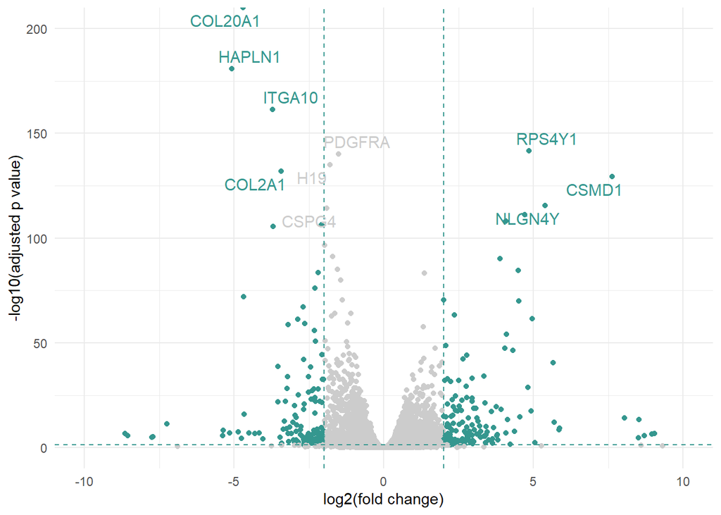

```r
# volcano plot - control vs A
ggplot(res_ctrl_A_df, aes(log2FoldChange, -log10(padj), color = threshold)) +
  geom_point() +
  geom_vline(xintercept = 2, linetype = 2, color = '#35978F')+
  geom_vline(xintercept = -2, linetype = 2, color = '#35978F') +
  geom_hline(yintercept = -log10(0.05), linetype = 2, color = "#35978F")+
  geom_text_repel(data = res_ctrl_A_df[1:10,],aes(log2FoldChange, -log10(padj), label = symbol), size = 4) +
  scale_color_manual(values = c('gray80', "#35978F"), guide="none") +
  xlim(-10, 10) +
  ylim(0, 200) +
  labs(x='log2(fold change)', y='-log10(adjusted p value)') +
  theme_minimal()
```

### shA vs shB

```r
#get the results
res_A_B <- results(dds, contrast = c('group', 'shH2AFY2a', 'shH2AFY2b'))
res_A_B
```

```
## log2 fold change (MLE): group shH2AFY2a vs shH2AFY2b
## Wald test p-value: group shH2AFY2a vs shH2AFY2b
## DataFrame with 22343 rows and 6 columns
##                     baseMean log2FoldChange     lfcSE       stat    pvalue
##                    <numeric>      <numeric> <numeric>  <numeric> <numeric>
## ENSG00000000003.15 1148.0299       0.209375  0.121282  1.7263421 0.0842859
## ENSG00000000419.14 1164.6156      -0.136368  0.131591 -1.0363052 0.3000598
## ENSG00000000457.14  332.2988       0.298897  0.201562  1.4829021 0.1381004
## ENSG00000000460.17  467.8580      -0.202312  0.185418 -1.0911113 0.2752239
## ENSG00000000971.17   31.1518       0.058050  0.633011  0.0917047 0.9269327
## ...                      ...            ...       ...        ...       ...
## ENSG00000291312.1    86.3567       0.329625  0.372542   0.884799  0.376265
## ENSG00000291313.1    60.1491      -0.426960  0.514345  -0.830104  0.406480
## ENSG00000291315.1   112.7547       0.177744  0.315020   0.564232  0.572596
## ENSG00000291316.1   328.7764       0.140301  0.252787   0.555014  0.578885
## ENSG00000291317.1   249.5546       0.111227  0.223377   0.497932  0.618532
##                         padj
##                    <numeric>
## ENSG00000000003.15  0.273201
## ENSG00000000419.14  0.596160
## ENSG00000000457.14  0.374035
## ENSG00000000460.17  0.568232
## ENSG00000000971.17  0.976934
## ...                      ...
## ENSG00000291312.1   0.677414
## ENSG00000291313.1   0.703651
## ENSG00000291315.1   0.822841
## ENSG00000291316.1   0.825546
## ENSG00000291317.1   0.846959
```

```r
# to data frame
res_A_B_df <- as_tibble(res_A_B, rownames = 'ENSEMBL')
res_A_B_df %>%
  arrange(padj)
```

```
## # A tibble: 22,343 × 7
##    ENSEMBL            baseMean log2FoldChange  lfcSE  stat    pvalue     padj
##    <chr>                 <dbl>          <dbl>  <dbl> <dbl>     <dbl>    <dbl>
##  1 ENSG00000129824.16     904.          -4.10 0.190  -21.6 9.39e-104 1.57e-99
##  2 ENSG00000054793.14    8576.           1.41 0.0656  21.5 3.80e-102 2.12e-98
##  3 ENSG00000132872.12    1150.           3.04 0.142   21.5 2.93e-102 2.12e-98
##  4 ENSG00000183117.20     511.          -6.78 0.316  -21.4 6.83e-102 2.85e-98
##  5 ENSG00000274290.3      462.          -3.61 0.177  -20.4 3.28e- 92 1.10e-88
##  6 ENSG00000175899.15    3068.           3.14 0.165   19.1 2.51e- 81 6.99e-78
##  7 ENSG00000067048.17     814.          -3.38 0.183  -18.5 4.66e- 76 1.11e-72
##  8 ENSG00000165246.15     830.          -4.17 0.234  -17.8 3.09e- 71 6.45e-68
##  9 ENSG00000104419.17    2410.          -2.63 0.150  -17.6 5.82e- 69 1.08e-65
## 10 ENSG00000012817.16     564.          -3.90 0.226  -17.2 1.41e- 66 2.35e-63
## # ℹ 22,333 more rows
```

```r
# ENSEMBL digits
res_A_B_df$ENSEMBL <- gsub('\\.\\d+', "", res_A_B_df$ENSEMBL)

# map ids
res_A_B_df$symbol <- mapIds(org.Hs.eg.db, keys = res_A_B_df$ENSEMBL, keytype = 'ENSEMBL', column = 'SYMBOL')
res_A_B_df %>%
  arrange(padj)
```

```
## # A tibble: 22,343 × 8
##    ENSEMBL        baseMean log2FoldChange  lfcSE  stat    pvalue     padj symbol
##    <chr>             <dbl>          <dbl>  <dbl> <dbl>     <dbl>    <dbl> <chr>
##  1 ENSG000001298…     904.          -4.10 0.190  -21.6 9.39e-104 1.57e-99 RPS4Y1
##  2 ENSG000000547…    8576.           1.41 0.0656  21.5 3.80e-102 2.12e-98 ATP9A
##  3 ENSG000001328…    1150.           3.04 0.142   21.5 2.93e-102 2.12e-98 SYT4
##  4 ENSG000001831…     511.          -6.78 0.316  -21.4 6.83e-102 2.85e-98 CSMD1
##  5 ENSG000002742…     462.          -3.61 0.177  -20.4 3.28e- 92 1.10e-88 H2BC6
##  6 ENSG000001758…    3068.           3.14 0.165   19.1 2.51e- 81 6.99e-78 A2M
##  7 ENSG000000670…     814.          -3.38 0.183  -18.5 4.66e- 76 1.11e-72 DDX3Y
##  8 ENSG000001652…     830.          -4.17 0.234  -17.8 3.09e- 71 6.45e-68 NLGN4Y
##  9 ENSG000001044…    2410.          -2.63 0.150  -17.6 5.82e- 69 1.08e-65 NDRG1
## 10 ENSG000000128…     564.          -3.90 0.226  -17.2 1.41e- 66 2.35e-63 KDM5D
## # ℹ 22,333 more rows
```

```r
# add threshold column
res_A_B_df <- res_A_B_df %>%
  mutate(threshold = (log2FoldChange > 2 & padj < 0.05) | (log2FoldChange < -2 & padj < 0.05))

#order the data
res_A_B_df <- res_A_B_df %>%
  arrange(padj)
res_A_B_df
```

```
## # A tibble: 22,343 × 9
##    ENSEMBL        baseMean log2FoldChange  lfcSE  stat    pvalue     padj symbol
##    <chr>             <dbl>          <dbl>  <dbl> <dbl>     <dbl>    <dbl> <chr>
##  1 ENSG000001298…     904.          -4.10 0.190  -21.6 9.39e-104 1.57e-99 RPS4Y1
##  2 ENSG000000547…    8576.           1.41 0.0656  21.5 3.80e-102 2.12e-98 ATP9A
##  3 ENSG000001328…    1150.           3.04 0.142   21.5 2.93e-102 2.12e-98 SYT4
##  4 ENSG000001831…     511.          -6.78 0.316  -21.4 6.83e-102 2.85e-98 CSMD1
##  5 ENSG000002742…     462.          -3.61 0.177  -20.4 3.28e- 92 1.10e-88 H2BC6
##  6 ENSG000001758…    3068.           3.14 0.165   19.1 2.51e- 81 6.99e-78 A2M
##  7 ENSG000000670…     814.          -3.38 0.183  -18.5 4.66e- 76 1.11e-72 DDX3Y
##  8 ENSG000001652…     830.          -4.17 0.234  -17.8 3.09e- 71 6.45e-68 NLGN4Y
##  9 ENSG000001044…    2410.          -2.63 0.150  -17.6 5.82e- 69 1.08e-65 NDRG1
## 10 ENSG000000128…     564.          -3.90 0.226  -17.2 1.41e- 66 2.35e-63 KDM5D
## # ℹ 22,333 more rows
## # ℹ 1 more variable: threshold <lgl>
```

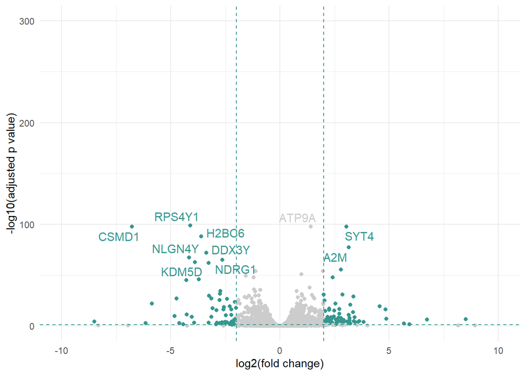

```r
# volcano plot - shA vs shB
ggplot(res_A_B_df, aes(log2FoldChange, -log10(padj), color = threshold)) +
  geom_point() +
  geom_vline(xintercept = 2, linetype = 2, color = '#35978F')+
  geom_vline(xintercept = -2, linetype = 2, color = '#35978F') +
  geom_hline(yintercept = -log10(0.05), linetype = 2, color = "#35978F")+
  geom_text_repel(data = res_A_B_df[1:10,],aes(log2FoldChange, -log10(padj), label = symbol), size = 4) +
  scale_color_manual(values = c('gray80', "#35978F"), guide="none") +
  xlim(-10, 10) +
  ylim(0, 300) +
  labs(x='log2(fold change)', y='-log10(adjusted p value)') +
  theme_minimal()
```

## I also compared all control vs treatment samples without spliting for knockout type

```r
# create new DESeqDataSet
dds_treatment <- DESeqDataSet(gse, design = ~ treatment)
```

```
## using counts and average transcript lengths from tximeta
```

```r
dds_treatment
```

```
## # A SummarizedExperiment-tibble abstraction: 373,614 × 6
## # Features=62269 | Samples=6 | Assays=counts, abundance, avgTxLength
##    .feature  .sample counts abundance avgTxLength names SampName treatment group
##    <chr>     <chr>    <int>     <dbl>       <dbl> <chr> <chr>    <fct>     <fct>
##  1 ENSG0000… SRR116…   1486   7.84          2184. SRR1… GSM4497… control   shScr
##  2 ENSG0000… SRR116…      0   0              624. SRR1… GSM4497… control   shScr
##  3 ENSG0000… SRR116…   1322  17.7            863. SRR1… GSM4497… control   shScr
##  4 ENSG0000… SRR116…    344   1.14          3491. SRR1… GSM4497… control   shScr
##  5 ENSG0000… SRR116…    608   3.91          1794. SRR1… GSM4497… control   shScr
##  6 ENSG0000… SRR116…      1   0.00549       2101  SRR1… GSM4497… control   shScr
##  7 ENSG0000… SRR116…     27   0.130         2358. SRR1… GSM4497… control   shScr
##  8 ENSG0000… SRR116…   1423  10.4           1579. SRR1… GSM4497… control   shScr
##  9 ENSG0000… SRR116…    625   4.95          1454. SRR1… GSM4497… control   shScr
## 10 ENSG0000… SRR116…   2212   7.60          3354. SRR1… GSM4497… control   shScr
## # ℹ 40 more rows
## # ℹ 7 more variables: gene_id <chr>, tx_ids <named list>, seqnames <fct>,
## #   start <int>, end <int>, width <int>, strand <fct>
```

```r
#filter the data
keep <- rowSums(counts(dds_treatment) >= 10) >= 2
dds_treatment <- dds_treatment[keep, ]


# differnatial expression analysis
dds_treatment <- DESeq(dds_treatment)
```

```
## using 'avgTxLength' from assays(dds), correcting for library size
```

```r
# get the results
res_treatment <- results(dds_treatment)
res_treatment
```

```
## log2 fold change (MLE): treatment knockdown vs control
## Wald test p-value: treatment knockdown vs control
## DataFrame with 22343 rows and 6 columns
##                     baseMean log2FoldChange     lfcSE       stat     pvalue
##                    <numeric>      <numeric> <numeric>  <numeric>  <numeric>
## ENSG00000000003.15 1148.0299     -0.3500837  0.135012  -2.592986 0.00951467
## ENSG00000000419.14 1164.6156     -0.0269944  0.130429  -0.206966 0.83603635
## ENSG00000000457.14  332.2988      0.0504440  0.194133   0.259842 0.79498557
## ENSG00000000460.17  467.8580     -0.3521305  0.169775  -2.074104 0.03806966
## ENSG00000000971.17   31.1518     -0.4760595  0.467810  -1.017634 0.30885204
## ...                      ...            ...       ...        ...        ...
## ENSG00000291312.1    86.3567      0.1618581  0.304324  0.5318604   0.594823
## ENSG00000291313.1    60.1491     -0.0229942  0.422925 -0.0543695   0.956641
## ENSG00000291315.1   112.7547      0.2771136  0.248286  1.1161057   0.264377
## ENSG00000291316.1   328.7764     -0.4159646  0.214963 -1.9350511   0.052984
## ENSG00000291317.1   249.5546      0.1957409  0.181632  1.0776792   0.281177
##                         padj
##                    <numeric>
## ENSG00000000003.15 0.0500351
## ENSG00000000419.14 0.9378395
## ENSG00000000457.14 0.9198163
## ENSG00000000460.17 0.1409649
## ENSG00000000971.17 0.5707401
## ...                      ...
## ENSG00000291312.1   0.808932
## ENSG00000291313.1   0.984568
## ENSG00000291315.1   0.519437
## ENSG00000291316.1   0.178476
## ENSG00000291317.1   0.539763
```

```r
# shrink LFC for better visualization
res_treatment_df <- lfcShrink(dds_treatment, coef = c('treatment_knockdown_vs_control'), type = 'apeglm')
```

```
## using 'apeglm' for LFC shrinkage. If used in published research, please cite:
##     Zhu, A., Ibrahim, J.G., Love, M.I. (2018) Heavy-tailed prior distributions for
##     sequence count data: removing the noise and preserving large differences.
##     Bioinformatics. https://doi.org/10.1093/bioinformatics/bty895
```

```r
res_treatment_df
```

```
## log2 fold change (MAP): treatment knockdown vs control
## Wald test p-value: treatment knockdown vs control
## DataFrame with 22343 rows and 5 columns
##                     baseMean log2FoldChange     lfcSE     pvalue      padj
##                    <numeric>      <numeric> <numeric>  <numeric> <numeric>
## ENSG00000000003.15 1148.0299     -0.3081767  0.131866 0.00951467 0.0500351
## ENSG00000000419.14 1164.6156     -0.0223683  0.119313 0.83603635 0.9378395
## ENSG00000000457.14  332.2988      0.0355728  0.162851 0.79498557 0.9198163
## ENSG00000000460.17  467.8580     -0.2875564  0.162502 0.03806966 0.1409649
## ENSG00000000971.17   31.1518     -0.1484749  0.281318 0.30885204 0.5707401
## ...                      ...            ...       ...        ...       ...
## ENSG00000291312.1    86.3567     0.08013412  0.218272   0.594823  0.808932
## ENSG00000291313.1    60.1491    -0.00699098  0.241847   0.956641  0.984568
## ENSG00000291315.1   112.7547     0.17271997  0.208614   0.264377  0.519437
## ENSG00000291316.1   328.7764    -0.31023730  0.203331   0.052984  0.178476
## ENSG00000291317.1   249.5546     0.14651433  0.162028   0.281177  0.539763
```

```r
# create data frame for results
res_treatment_df <- as_tibble(res_treatment_df, rownames = 'ENSEMBL')
res_treatment_df %>%
  arrange(padj)
```

```
## # A tibble: 22,343 × 6
##    ENSEMBL            baseMean log2FoldChange  lfcSE    pvalue      padj
##    <chr>                 <dbl>          <dbl>  <dbl>     <dbl>     <dbl>
##  1 ENSG00000101203.17    9433.           4.78 0.137  6.92e-267 1.37e-262
##  2 ENSG00000183775.11    1301.           2.29 0.113  5.57e- 93 5.49e- 89
##  3 ENSG00000090006.18    3600.           1.70 0.0843 6.26e- 92 4.12e- 88
##  4 ENSG00000175274.19     885.           4.73 0.241  1.97e- 87 9.73e- 84
##  5 ENSG00000128683.14   11009.           2.02 0.107  5.24e- 80 2.07e- 76
##  6 ENSG00000187479.9      760.           2.58 0.155  3.11e- 63 1.02e- 59
##  7 ENSG00000143127.13    1509.           3.46 0.214  3.52e- 60 9.94e- 57
##  8 ENSG00000113749.8      725.           3.01 0.190  3.19e- 58 7.88e- 55
##  9 ENSG00000064655.19     130.          -4.79 0.312  6.95e- 54 1.52e- 50
## 10 ENSG00000169427.8     1520.           2.36 0.157  2.32e- 52 4.58e- 49
## # ℹ 22,333 more rows
```

```r
# remove digits
res_treatment_df$ENSEMBL <- gsub('\\.\\d+', "", res_treatment_df$ENSEMBL)

# map ENSEMBL IDs to gene symbols
res_treatment_df$symbol <- mapIds(org.Hs.eg.db, keys = res_treatment_df$ENSEMBL, keytype = 'ENSEMBL', column = 'SYMBOL')
#check
res_treatment_df %>%
  arrange(padj)
```

```
## # A tibble: 22,343 × 7
##    ENSEMBL         baseMean log2FoldChange  lfcSE    pvalue      padj symbol
##    <chr>              <dbl>          <dbl>  <dbl>     <dbl>     <dbl> <chr>
##  1 ENSG00000101203    9433.           4.78 0.137  6.92e-267 1.37e-262 COL20A1
##  2 ENSG00000183775    1301.           2.29 0.113  5.57e- 93 5.49e- 89 KCTD16
##  3 ENSG00000090006    3600.           1.70 0.0843 6.26e- 92 4.12e- 88 LTBP4
##  4 ENSG00000175274     885.           4.73 0.241  1.97e- 87 9.73e- 84 TP53I11
##  5 ENSG00000128683   11009.           2.02 0.107  5.24e- 80 2.07e- 76 GAD1
##  6 ENSG00000187479     760.           2.58 0.155  3.11e- 63 1.02e- 59 C11orf96
##  7 ENSG00000143127    1509.           3.46 0.214  3.52e- 60 9.94e- 57 ITGA10
##  8 ENSG00000113749     725.           3.01 0.190  3.19e- 58 7.88e- 55 HRH2
##  9 ENSG00000064655     130.          -4.79 0.312  6.95e- 54 1.52e- 50 EYA2
## 10 ENSG00000169427    1520.           2.36 0.157  2.32e- 52 4.58e- 49 KCNK9
## # ℹ 22,333 more rows
```

```r
# add thershold column
res_treatment_df <- res_treatment_df %>%
  mutate(threshold = (log2FoldChange > 2 & padj < 0.05) | (log2FoldChange < -2 & padj < 0.05))
# order the data frame
res_treatment_df <- res_treatment_df %>%
  arrange(padj)
res_treatment_df
```

```
## # A tibble: 22,343 × 8
##    ENSEMBL   baseMean log2FoldChange  lfcSE    pvalue      padj symbol threshold
##    <chr>        <dbl>          <dbl>  <dbl>     <dbl>     <dbl> <chr>  <lgl>
##  1 ENSG0000…    9433.           4.78 0.137  6.92e-267 1.37e-262 COL20… TRUE
##  2 ENSG0000…    1301.           2.29 0.113  5.57e- 93 5.49e- 89 KCTD16 TRUE
##  3 ENSG0000…    3600.           1.70 0.0843 6.26e- 92 4.12e- 88 LTBP4  FALSE
##  4 ENSG0000…     885.           4.73 0.241  1.97e- 87 9.73e- 84 TP53I… TRUE
##  5 ENSG0000…   11009.           2.02 0.107  5.24e- 80 2.07e- 76 GAD1   TRUE
##  6 ENSG0000…     760.           2.58 0.155  3.11e- 63 1.02e- 59 C11or… TRUE
##  7 ENSG0000…    1509.           3.46 0.214  3.52e- 60 9.94e- 57 ITGA10 TRUE
##  8 ENSG0000…     725.           3.01 0.190  3.19e- 58 7.88e- 55 HRH2   TRUE
##  9 ENSG0000…     130.          -4.79 0.312  6.95e- 54 1.52e- 50 EYA2   TRUE
## 10 ENSG0000…    1520.           2.36 0.157  2.32e- 52 4.58e- 49 KCNK9  TRUE
## # ℹ 22,333 more rows
```

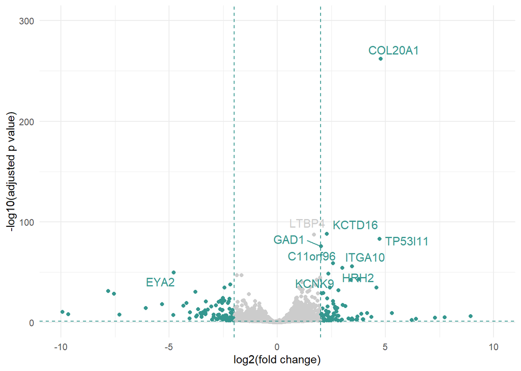

```r
# volcano plot - control vs treatment
ggplot(res_treatment_df, aes(log2FoldChange, -log10(padj), color = threshold)) +
  geom_point() +
  geom_vline(xintercept = 2, linetype = 2, color = '#35978F')+
  geom_vline(xintercept = -2, linetype = 2, color = '#35978F') +
  geom_hline(yintercept = -log10(0.05), linetype = 2, color = "#35978F")+
  geom_text_repel(data = res_treatment_df[1:10,],aes(log2FoldChange, -log10(padj), label = symbol), size = 4) +
  scale_color_manual(values = c('gray80', "#35978F"), guide="none") +
  xlim(-10, 10) +
  ylim(0, 300) +
  labs(x='log2(fold change)', y='-log10(adjusted p value)') +
  theme_minimal()
```

## Heatmap

I picked 50 genes with the biggest variance across the samples and made the heatmap (`ComplexHeatmap` package)

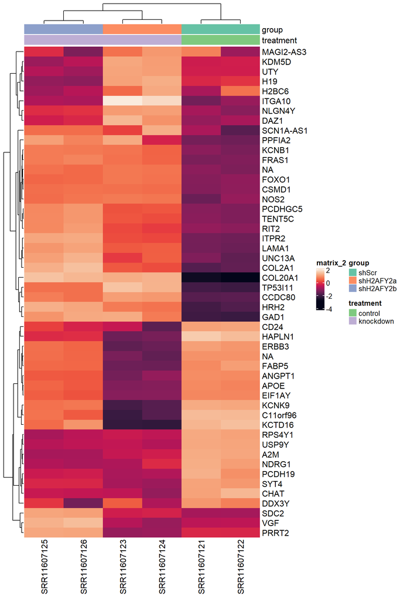

```r
# get top variable genes
topVarGenes <- head(order(rowVars(assay(rld)), decreasing = TRUE), 50)


# make heatmap with pheatmap package
mat <- assay(rld)[topVarGenes, ]
mat <- mat - rowMeans(mat)
anno <- as.data.frame(colData(rld)[,c('group', 'treatment')])
rownames(mat) <- gsub('\\.\\d+', "", rownames(mat))
symbols <- res_treatment_df[which(res_treatment_df$ENSEMBL %in% rownames(mat)), ]$symbol

# choose the colors
pal_1 <- rep(brewer.pal(3,'Set2'), each=2)
names(pal_1) <- anno$group

pal_2 <- rep(brewer.pal(3, 'Accent')[1:2], c(2,4))
names(pal_2) <- anno$treatment

# create named list of colors
cols <- list(pal_1, pal_2)
names(cols) <- c('group', 'treatment')

#create annotation data frame
anno <- as.data.frame(colData(rld)[,c('group', 'treatment')])
anno <- HeatmapAnnotation(df = anno, col = cols)

#make Heatmap
Heatmap(mat, col = (viridis::rocket(100)), row_labels = symbols, top_annotation = anno)
```

## Venn diagram

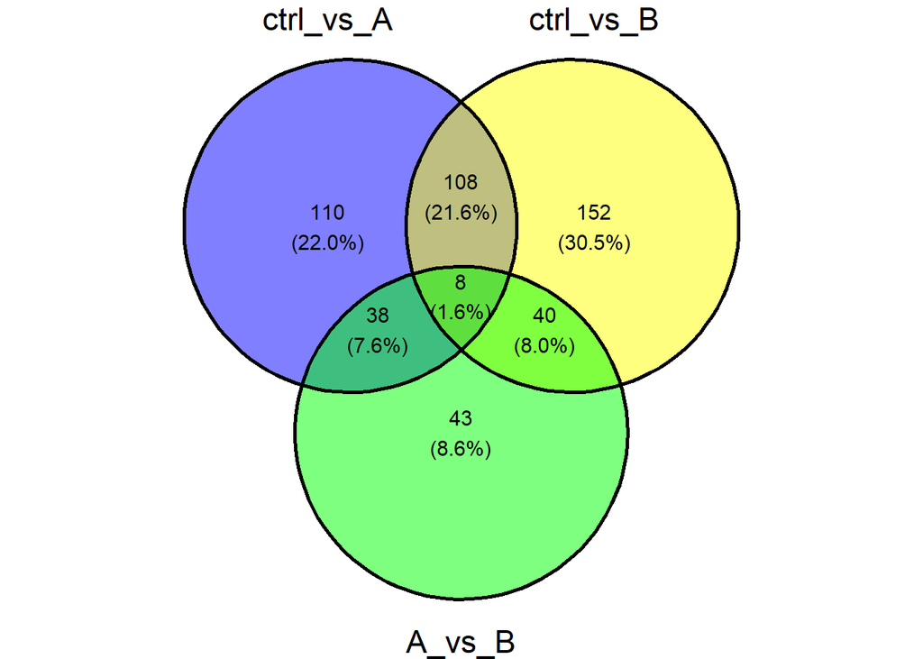

```r
#prepare the data

res_ctrl_B_top <- res_ctrl_B_df %>%
  filter((log2FoldChange > 2 & padj < 0.05) | (log2FoldChange < -2 & padj < 0.05))
res_ctrl_B_top <- res_ctrl_B_top$symbol
res_ctrl_A_top <- res_ctrl_A_df %>%
  filter((log2FoldChange > 2 & padj < 0.05) | (log2FoldChange < -2 & padj < 0.05))
res_ctrl_A_top <- res_ctrl_A_top$symbol
res_A_B_df_top <- res_A_B_df %>%
  filter((log2FoldChange > 2 & padj < 0.05) | (log2FoldChange < -2 & padj < 0.05))
res_A_B_df_top <- res_A_B_df_top$symbol
venn_list <- list('ctrl_vs_A' = res_ctrl_A_top, 'ctrl_vs_B' = res_ctrl_B_top, 'A_vs_B' = res_A_B_df_top)


ggvenn(venn_list, c('ctrl_vs_A', 'ctrl_vs_B', 'A_vs_B'))
```

Common genes with significant changes between samples

## Functional enrichment analysis

I picked genes with significantly altered expression with log2 fold change bigger than 1  
Then I mapped the symbol to ENTERZ ID in order to perform enrichment analysis with `clusterProfiler`

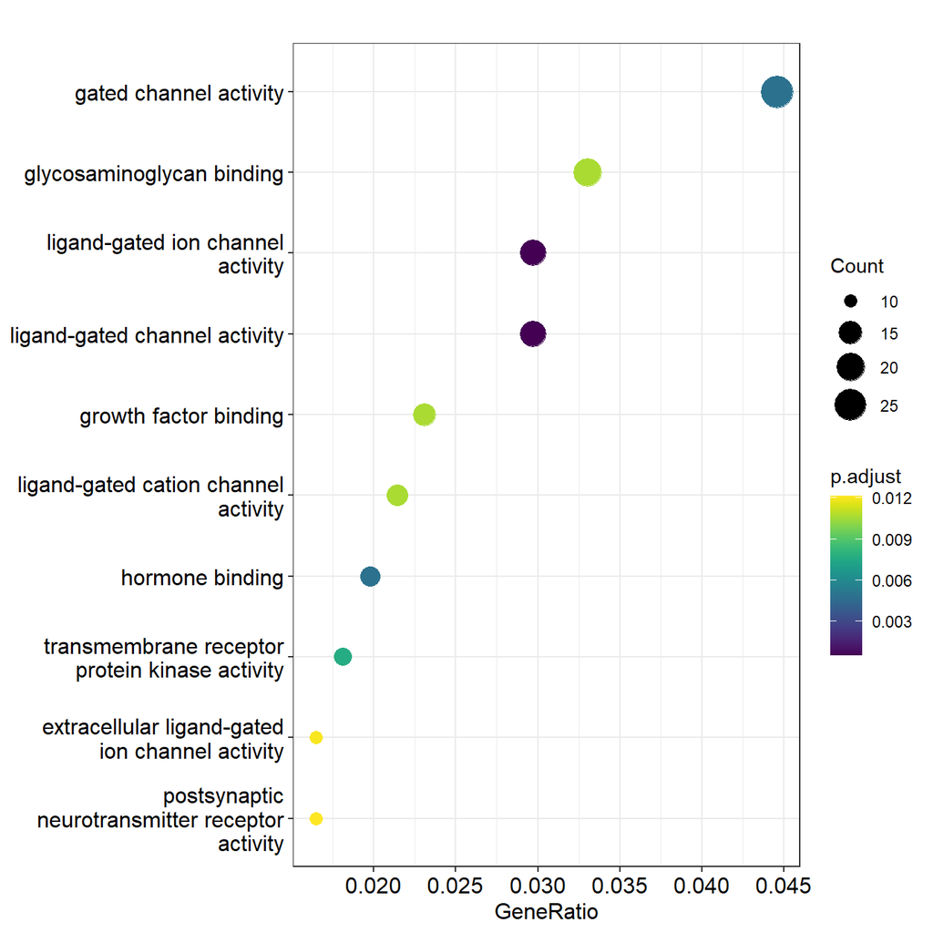

```r
#get the top genes
res_treat_top <- res_treatment_df %>%
  arrange(padj, desc(log2FoldChange)) %>%
  filter((log2FoldChange > 1 & padj < 0.05) | (log2FoldChange < -1 & padj < 0.05))

# get the symbol and map it to Enterz ID
res_treat_top <- res_treat_top$symbol
res_teat_entrez <- mapIds(org.Hs.eg.db, keys = res_treat_top, keytype = 'SYMBOL', column = 'ENTREZID')
# perform GO enrichment analysis
ego <- enrichGO(res_teat_entrez, org.Hs.eg.db)

dotplot(ego) + scale_color_gradientn(colors = viridis::viridis(100))
```

Analysis showed some interesting enriched pathways such as gated channel activity and neurotransmitter receptor activity (glioblastoma study) also growth factor binding (cancer-related pathway)

### Further visualization

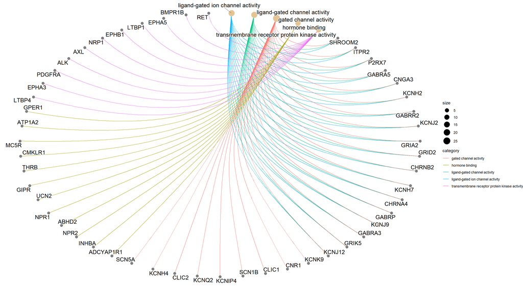

```r
#visualization
egox <- setReadable(ego, 'org.Hs.eg.db', "ENTREZID")

res_treat_top <- res_treatment_df

FC_data <- res_treat_top$log2FoldChange

cnetplot(egox, foldChange = FC_data, circular=T, colorEdge=T)
```

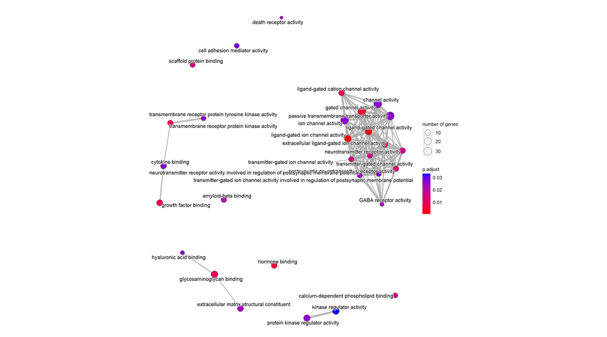

```r
sig_gene_er <- pairwise_termsim(ego)
emapplot(sig_gene_er, cex_label_category = 0.8)
```

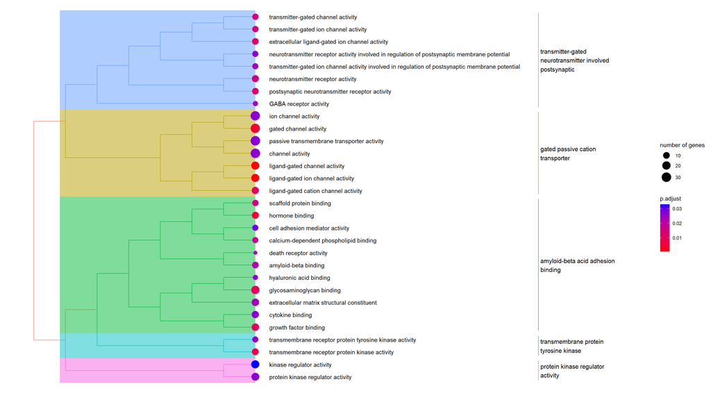

```r
egox2 <- pairwise_termsim(egox)
treeplot(egox2)
```

GO analysis with `gprofiler2`

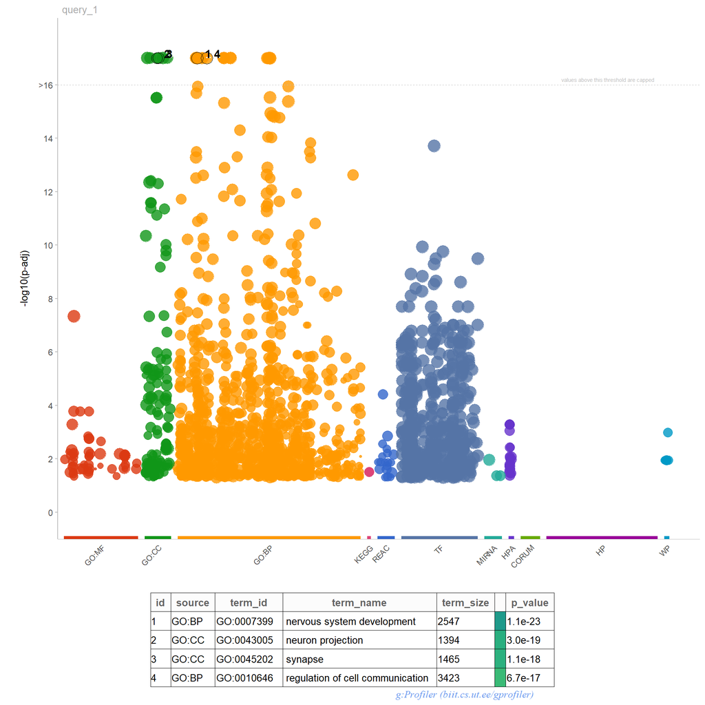

[figure not shown]

```r
res_treat_top <- res_treatment_df %>%
  arrange(padj, desc(log2FoldChange)) %>%
  filter((log2FoldChange > 1 & padj < 0.05) | (log2FoldChange < -1 & padj < 0.05))


res_treat_top <- res_treat_top$symbol

gprof_go <- gost(res_treat_top, organism = 'hsapiens', correction_method = 'fdr')


#gostplot(gprof_go, interactive = T, capped = T)
go_plot <- gostplot(gprof_go, interactive = F, capped = T)
publish_gostplot(go_plot,
                 highlight_terms = c('GO:0007399', 'GO:0043005', 'GO:0045202', 'GO:0010646'))
```

## GSEA

```r
res_treat_top <- res_treatment_df



gsea_data <- res_treat_top$log2FoldChange

names(gsea_data) <- res_treat_top$symbol

names(gsea_data) <- mapIds(org.Hs.eg.db, keys = names(gsea_data), keytype = 'SYMBOL', column = 'ENTREZID')
gsea_data <- gsea_data[order(gsea_data, decreasing=T)]




library(msigdbr)
hs_c2 <-msigdbr(species = "Homo sapiens", category = 'C2')[,c('gs_name', 'entrez_gene')]

gsea_C2 <- GSEA(gsea_data, TERM2GENE = hs_c2)
```

```
## preparing geneSet collections...
```

```
## GSEA analysis...
```

```
## leading edge analysis...
```

```
## done...
```

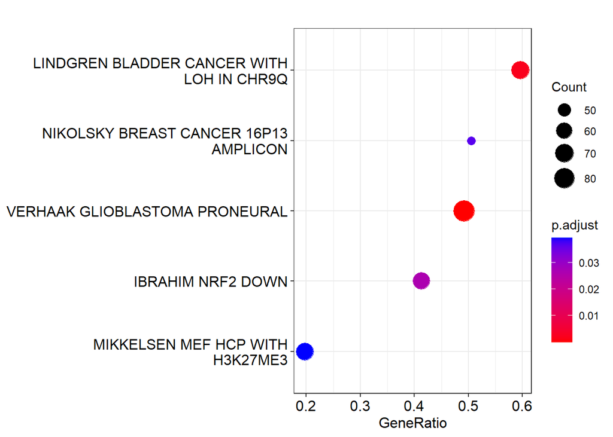

```r
dotplot(gsea_C2)
```

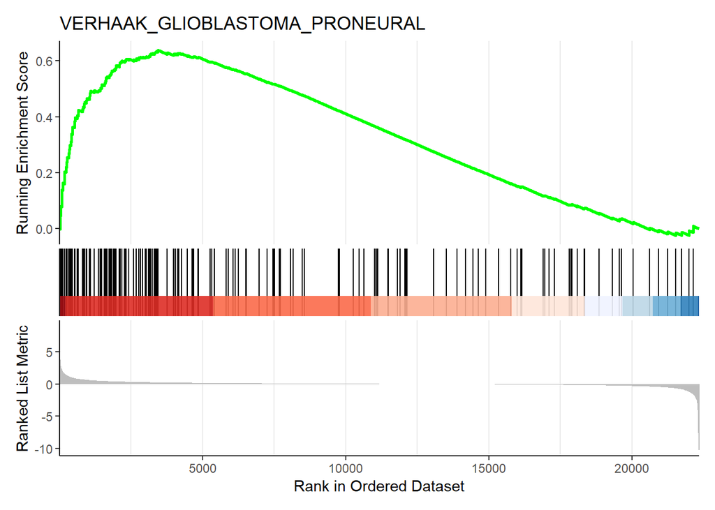

```r
gseaplot2(gsea_C2, geneSetID = 1, title = 'VERHAAK_GLIOBLASTOMA_PRONEURAL')
```

```r
hs_C8 <-msigdbr(species = "Homo sapiens", category = 'C8')[,c('gs_name', 'entrez_gene')]

gsea_C8 <- GSEA(gsea_data, TERM2GENE = hs_C8)
```

```
## preparing geneSet collections...
```

```
## GSEA analysis...
```

```
## leading edge analysis...
```

```
## done...
```

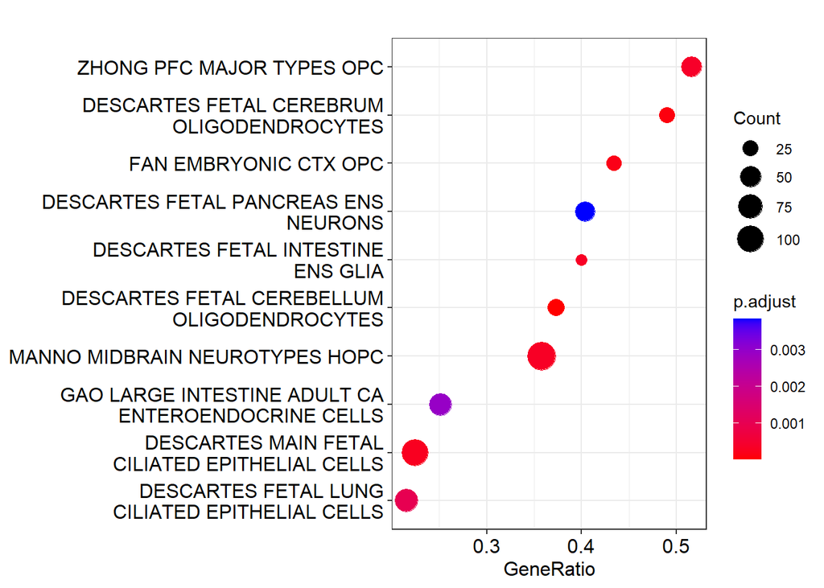

```r
dotplot(gsea_C8)
```

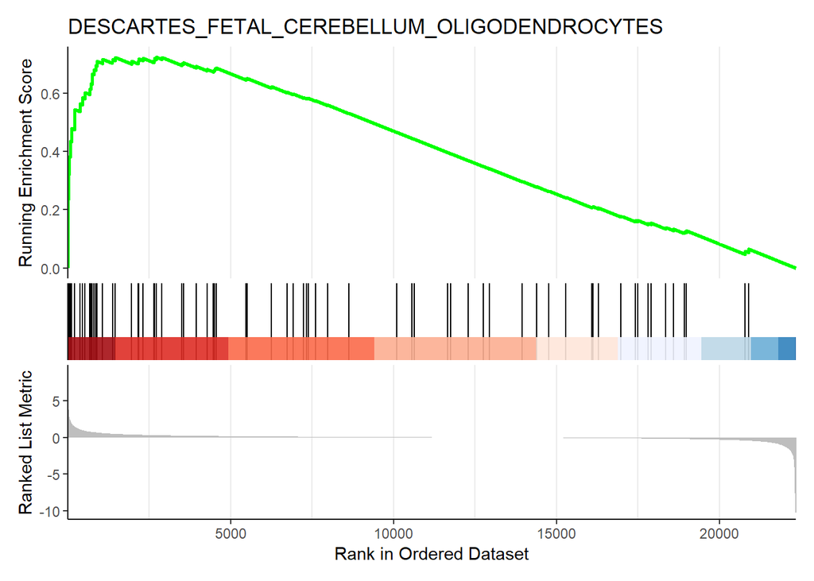

```r
gseaplot2(gsea_C8, geneSetID = 1, title = 'DESCARTES_FETAL_CEREBELLUM_OLIGODENDROCYTES')
```

GSEA analysis showed among others gene set enrichment found in previous giloblastoma studies